# Assignment 3

## Submit as an HTML file

Print your Emory ID below

```python
emory_id = 2486577
print(f"My Emory ID is {emory_id}")
```

```
My Emory ID is 2486577
```

```python
from pyfiglet import Figlet

emory_id = 2486577

f = Figlet(font='slant')
print(f.renderText(f'Emory ID: {emory_id}'))
```

```
    ______                              ________
   / ____/___ ___  ____  _______  __   /  _/ __ \_
  / __/ / __ `__ \/ __ \/ ___/ / / /   / // / / (_)
 / /___/ / / / / / /_/ / /  / /_/ /  _/ // /_/ /
/_____/_/ /_/ /_/\____/_/   \__, /  /___/_____(_)
                           /____/
   ___  __ __  ____  _____ ________________
  |__ \/ // / ( __ )/ ___// ____/__  /__  /
  __/ / // /_/ __  / __ \/___ \   / /  / /
 / __/__  __/ /_/ / /_/ /___/ /  / /  / /
/____/ /_/  \____/\____/_____/  /_/  /_/
```

```python
from termcolor import colored

emory_id = 2486577
print(colored(f"✨ Emory ID: ", "cyan") + colored(f"{emory_id}", "yellow", attrs=["bold", "blink"]))
```

```
✨ Emory ID: 2486577
```

```python
from IPython.display import HTML

emory_id = 2486577
html_code = f"""
<div style="
    border: 2px solid #3498db;
    padding: 20px;
    border-radius: 10px;
    background: linear-gradient(45deg, #f3f9ff, #e0f0ff);
    font-family: Arial;
    text-align: center;
    box-shadow: 0 4px 8px rgba(0,0,0,0.1);
">
    <h2 style="color: #2c3e50; margin: 0;">🔖 Emory ID</h2>
    <p style="font-size: 24px; color: #e74c3c; font-weight: bold;">{emory_id}</p>
</div>
"""

HTML(html_code)
```

🔖 Emory ID

2486577

```python
emory_id = 2486577
print(f"\n🔮✨ \033[1mEmory ID:\033[0m \033[3;34m{emory_id}\033[0m ✨🔮\n")
```

```
🔮✨ Emory ID: 2486577 ✨🔮
```

Import the numpy and matplotlib packages

```python
import numpy as np
import matplotlib.pyplot as plt
```

(a) Compute a formula:

The formula for the volume of a cone is:

$V = \frac{1}{3} \pi r^2 h$

Where:

- $V$ is the volume of the cone
- $r$ is the radius of the base
- $h$ is the height of the cone

Calculate $V$ when:

- $r = 5$
- $h = 10$

To get full points:

- First define each of these variables
- Write the formula above
- Print out the result

```python
r = 5
h = 10
V = (1/3) * np.pi * r**2 * h
print(f"The volume of the cone is: {V:.2f}")
```

```
The volume of the cone is: 261.80
```

```python
import numpy as np

def cone_volume(r, h):
    V = (1/3) * np.pi * r**2 * h
    return V

# Define the variables
r = 5
h = 10

volume = cone_volume(r, h)
print(f"The volume of the cone is: {volume:.2f}")
```

```
The volume of the cone is: 261.80
```

(b) Composite operations on arrays

- Define r = 0.1
- Define x = 1
- Define two arrays $A$ and $T$ using "np.array()", assigning the following values

$ a = \begin{pmatrix} a_1 \\ a_2 \\ a_3 \end{pmatrix} = \begin{pmatrix} 28 \\ 32 \\ 11 \end{pmatrix}, \qquad t = \begin{pmatrix} t_1 \\ t_2 \\ t_3 \end{pmatrix} = \begin{pmatrix} 4 \\ 5 \\ 6 \end{pmatrix} $

- Use element-by-element vector operations to compute a new array $M$ of length 3:

$ M = \begin{pmatrix} a_1 \cdot (1+r)^{t_1} + cos(x) \\ a_2 \cdot (1+r)^{t_2} + cos(x) \\ a_3 \cdot (1+r)^{t_3} + cos(x) \end{pmatrix} $

- Compute the sum of the values of $M$ using "M.sum()"

Note: I am using subscripts to denote the individual elements of $a$ and $t$.

- In the code just enter the values of $a$ and $t$.
- To get full points you must do all of the above tasks

```python
import numpy as np
import matplotlib.pyplot as plt

r = 0.1
x = 1

a = np.array([28, 32, 11])
t = np.array([4, 5, 6])

M = a * (1 + r) ** t + np.cos(x)

print("Array M:", M)

M_sum = M.sum()

print("Sum of values in M:", M_sum)
```

```
Array M: [41.53510231 52.07662231 20.02747331]
Sum of values in M: 113.63919791760446
```

(c) Plot a normal random variable

To get full points:

- Set a seed using "np.random.seed()"
- Create the random variable with the following parameters
- mean = 233, standard deviation = 99, and size = 1314
- Create a histogram
- Label the axes

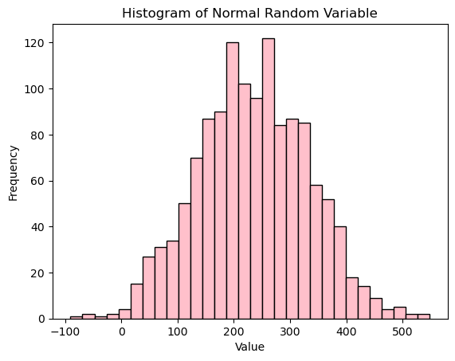

```python
import numpy as np
import matplotlib.pyplot as plt

np.random.seed(10086)

# Create the rv
mean = 233
std_dev = 99
size = 1314
random_variable = np.random.normal(mean, std_dev, size)

plt.hist(random_variable, bins=30, color='pink', edgecolor='black')
plt.xlabel("Value")
plt.ylabel("Frequency")
plt.title("Histogram of Normal Random Variable")
plt.show()
```

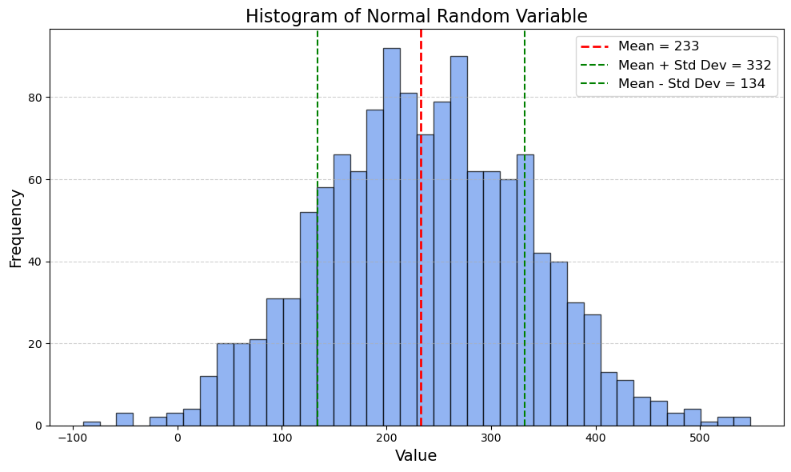

```python
import numpy as np
import matplotlib.pyplot as plt

np.random.seed(10086)

mean = 233
std_dev = 99
size = 1314
random_variable = np.random.normal(mean, std_dev, size)

plt.figure(figsize=(10, 6))
plt.hist(random_variable, bins=40, color='cornflowerblue', edgecolor='black', alpha=0.7)
plt.xlabel("Value", fontsize=14)
plt.ylabel("Frequency", fontsize=14)
plt.title("Histogram of Normal Random Variable", fontsize=16)
plt.grid(axis='y', linestyle='--', alpha=0.6)
plt.axvline(mean, color='red', linestyle='dashed', linewidth=2, label=f"Mean = {mean}")
plt.axvline(mean + std_dev, color='green', linestyle='dashed', linewidth=1.5, label=f"Mean + Std Dev = {mean + std_dev}")
plt.axvline(mean - std_dev, color='green', linestyle='dashed', linewidth=1.5, label=f"Mean - Std Dev = {mean - std_dev}")
plt.legend(fontsize=12)

plt.tight_layout()
plt.show()
```

(d) Checking whether word is part of list

- Define a variable "QSS" with the value "Statistics"
- Define a list of fruits with the values list_QSS = ["Statistics", "CS", "Dara Science", "Math"]
- Write an expression to test whether "QSS" is contained in "list_QSS"

Hint: Use the "in" command. The final output should be True/False.

To get full points run all of the above commands

```python
QSS = "Statistics"
list_QSS = ["Statistics", "CS", "Dara Science", "Math"]

print(QSS in list_QSS)
```

```
True
```

(e) Classifying a variable

- Define a new variable "film_score" and assign it "70"
- Write an if/else statement that does the following
  - print("Box-office Success") if the score is strictly above 80.
  - print("Intermediate Range") if the score is weakly less than 80 and strictly above 20.
  - print("Box-office Failure") if the score does not fit in the above categories.

To get full points you must do all of the above instructions

```python
film_score = 70

if film_score > 80:
    print("Box-office Success")
elif 20 < film_score <= 80:
    print("Intermediate Range")
else:
    print("Box-office Failure")
```

```
Intermediate Range
```

```python
film_score = 70

def classify_film(score):
    if score > 80:
        return "Box-office Success"
    elif 20 < score <= 80:
        return "Intermediate Range"
    else:
        return "Box-office Failure"

print(classify_film(film_score))
```

```
Intermediate Range
```